# Task2

## Import data

My keras installation doesn't seem to have california housing dataset so I will be importing it manually

This might because of the version of tensorflow I am using to be able to use cuda.

```python
import matplotlib.pyplot as plt
import numpy as np
from tensorflow.keras.models import Sequential
from tensorflow.keras.layers import Input, Dense
import tensorflow.keras.datasets as tfds
import pandas as pd

import pkgutil
from sklearn.model_selection import train_test_split

package = tfds
for importer, modname, ispkg in pkgutil.iter_modules(package.__path__):
    print('Found submodule %s (is a package: %s)' % (modname, ispkg))

# Looks like my tf doesnt have california housing data.

# I will have to import it manually
uri=r'C:\Users\markus\.keras\cal_housing\CaliforniaHousing\cal_housing.data'
california_data = pd.read_csv(uri, header=None)

# Shuffle the data
# california_data = california_data.sample(frac=1, random_state=42).reset_index(drop=True)

# Take 600 rows for use
california_data = california_data.head(600)

# Split california_data into features and target
features = california_data.iloc[:, :-1].values
target = california_data.iloc[:, -1].values

# Train test split 0.2
inputs, x_test, targets, y_test = train_test_split(features, target, test_size=0.2, random_state=42)

print(inputs.shape, targets.shape)
print(x_test.shape, y_test.shape)

print("And we have imported the data succesfully :)")
```

```
Found submodule boston_housing (is a package: True)
Found submodule cifar10 (is a package: True)
Found submodule cifar100 (is a package: True)
Found submodule fashion_mnist (is a package: True)
Found submodule imdb (is a package: True)
Found submodule mnist (is a package: True)
Found submodule reuters (is a package: True)
(480, 8) (480,)
(120, 8) (120,)
And we have imported the data succesfully :)
```

## Extract sets for training and validation

```python
# Extract sets for training and validation
x_train = inputs[:380]
y_train = targets[:380]
x_val = inputs[380:]
y_val = targets[380:]

print("Training set shapes:", x_train.shape, y_train.shape)
print("Validation set shapes:", x_val.shape, y_val.shape)
```

```
Training set shapes: (380, 8) (380,)
Validation set shapes: (100, 8) (100,)
```

## Standardize the data

We will standardize the data using the mean and standard deviation of the training set. Note that we will use the mean and standard deviation of the training set to standardize the validation set.

```python
mean = x_train.mean(axis=0) # mean and standard deviation computed from training set only
std = x_train.std(axis=0)
x_train -= mean
x_train /= std
x_test -= mean
x_test /= std
x_val -= mean
x_val /= std
y_train /= 1e5
y_test /= 1e5
y_val /= 1e5
```

## Create models

We will try 3 models:

```python
model1label = "Simpler network"
model1 = Sequential([
    Input(shape=(8,)),
    Dense(64, activation='relu'),
    Dense(64, activation='relu'),
    Dense(1)
])

model2label = "Deeper network"
model2 = Sequential([
    Input(shape=(8,)),
    Dense(128, activation='relu'),
    Dense(64, activation='relu'),
    Dense(1)
])

model3label="Wider network"
model3 = Sequential([
    Input(shape=(8,)),
    Dense(256, activation='relu'),
    Dense(128, activation='relu'),
    Dense(64, activation='relu'),
    Dense(1)
])

labels = [model1label, model2label, model3label]
models = [model1, model2, model3]

# configure the learning algorithm
# use same metrics for all models
for model in models:
    model.compile(optimizer='adam',loss='mse',metrics=['mae'])
    model.summary()
```

[output not shown]

## Train the models

```python
# Train model 1
history1 = model1.fit(x_train, y_train, epochs=500, batch_size=32, validation_data=(x_val, y_val), verbose=0)

# Train model 2
history2 = model2.fit(x_train, y_train, epochs=500, batch_size=32, validation_data=(x_val, y_val), verbose=0)

# Train model 3
history3 = model3.fit(x_train, y_train, epochs=500, batch_size=32, validation_data=(x_val, y_val), verbose=0)
```

## Evaluate the models

Plot the training and validation loss for each model to visualize the training process and determine if the model is overfitting. Plot the MAE of the models aswell. We will discard few epochs to get a better visualization of the model metrics. We will evaluate the models using the test set and compare the results to determine the best model.

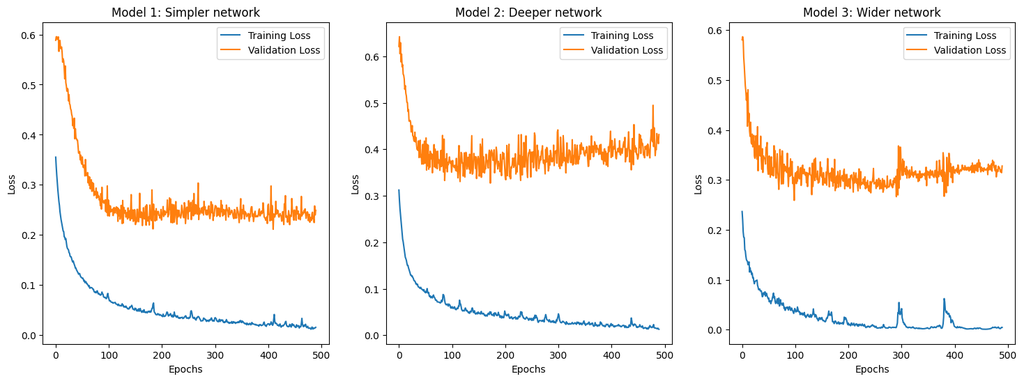

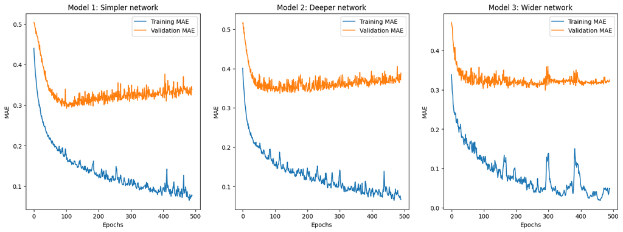

```
Model 1 - Test Loss: 0.206073597073555, Test MAE: 0.3139807879924774
Model 2 - Test Loss: 0.1866002231836319, Test MAE: 0.304307758808136
Model 3 - Test Loss: 0.19035834074020386, Test MAE: 0.29025307297706604
```

```python
# Epochs to discard
mae_discard = 10
loss_discard = 10

# Plot training and validation loss for each model
plt.figure(figsize=(18, 6))

for i, history in enumerate([history1, history2, history3], 1):
    plt.subplot(1, 3, i)
    plt.plot(history.history['loss'][loss_discard:], label='Training Loss')
    plt.plot(history.history['val_loss'][loss_discard:], label='Validation Loss')
    plt.title(f'Model {i}: '+labels[i-1])
    plt.xlabel('Epochs')
    plt.ylabel('Loss')
    plt.legend()

# Plot training and validation MAE for each model
plt.figure(figsize=(18, 6))

for i, history in enumerate([history1, history2, history3], 1):
    plt.subplot(1, 3, i)
    plt.plot(history.history['mae'][mae_discard:], label='Training MAE')
    plt.plot(history.history['val_mae'][mae_discard:], label='Validation MAE')
    plt.title(f'Model {i}: '+labels[i-1])
    plt.xlabel('Epochs')
    plt.ylabel('MAE')
    plt.legend()

plt.show()

# Evaluate the models using the test set
test_loss1, test_mae1 = model1.evaluate(x_test, y_test, verbose=0)
test_loss2, test_mae2 = model2.evaluate(x_test, y_test, verbose=0)
test_loss3, test_mae3 = model3.evaluate(x_test, y_test, verbose=0)

print(f"Model 1 - Test Loss: {test_loss1}, Test MAE: {test_mae1}")
print(f"Model 2 - Test Loss: {test_loss2}, Test MAE: {test_mae2}")
print(f"Model 3 - Test Loss: {test_loss3}, Test MAE: {test_mae3}")
```

## Choose the best model

We will choose the model with the lowest validation loss as the best model.

```python
# Extract the validation losses for each model
val_loss1 = min(history1.history['val_loss'])
val_loss2 = min(history2.history['val_loss'])
val_loss3 = min(history3.history['val_loss'])

# Determine the best model based on the lowest validation loss
best_model_index = np.argmin([val_loss1, val_loss2, val_loss3])
best_model = models[best_model_index]
best_model_label = labels[best_model_index]

print(f"The best model is Model {best_model_index + 1}: {best_model_label} with a validation loss of {min([val_loss1, val_loss2, val_loss3])}")
```

```
The best model is Model 1: Simpler network with a validation loss of 0.21119742095470428
```

## Avoiding overfitting

We will try few different techniques to avoid overfitting:

- Early stopping
- Dropout
- L2 regularization
- Smaller model

After this we will train the model one last time with the validation sets combined, and evaluate it with the test set.

```python
from tensorflow.keras.layers import Dropout
from tensorflow.keras.callbacks import EarlyStopping
from tensorflow.keras.regularizers import l2
from tensorflow.keras.layers import BatchNormalization

# Define early stopping callback
early_stopping = EarlyStopping(patience=300, restore_best_weights=True, monitor='val_mae')

# Modify the best model to include dropout layers
final_model = Sequential([
    Input(shape=(8,)),
    Dense(64, activation='relu'),
    BatchNormalization(),
    Dropout(0.5),
    Dense(25, activation='relu'), # 25 was best
    BatchNormalization(),
    Dropout(0.5),
    Dense(1)
])

# Compile model
final_model.compile(optimizer='adam', loss='mse', metrics=['mae'])

# Fit model
history_final = final_model.fit(x_train, y_train, epochs=1000, batch_size=32, validation_data=(x_val, y_val), callbacks=[early_stopping])
```

### Evaluate and visualize the best models

```
Final Model - Test Loss: 0.15617240965366364, Test MAE: 0.2951785922050476
```

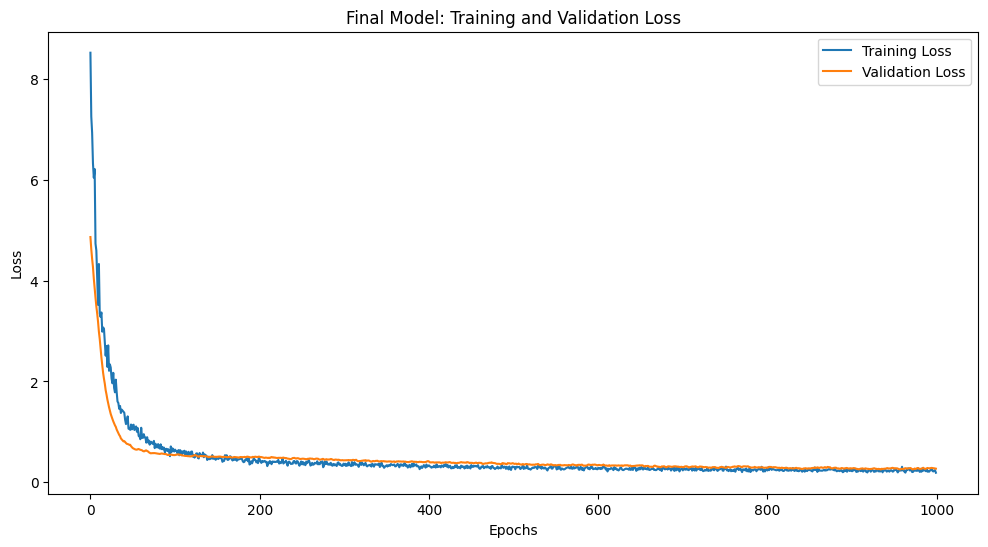

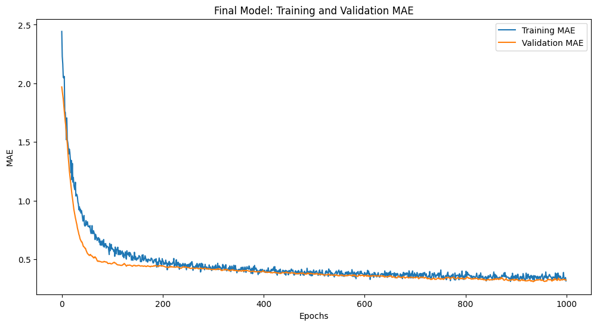

```python
# Evaluate the final model using the test set
final_test_loss, final_test_mae = final_model.evaluate(x_test, y_test, verbose=0)

print(f"Final Model - Test Loss: {final_test_loss}, Test MAE: {final_test_mae}")

# Plot training and validation loss for the final model
plt.figure(figsize=(12, 6))
plt.plot(history_final.history['loss'], label='Training Loss')
plt.plot(history_final.history['val_loss'], label='Validation Loss')
plt.title('Final Model: Training and Validation Loss')
plt.xlabel('Epochs')
plt.ylabel('Loss')
plt.legend()
plt.show()

# Plot training and validation MAE for the final model
plt.figure(figsize=(12, 6))
plt.plot(history_final.history['mae'], label='Training MAE')
plt.plot(history_final.history['val_mae'], label='Validation MAE')
plt.title('Final Model: Training and Validation MAE')
plt.xlabel('Epochs')
plt.ylabel('MAE')
plt.legend()
plt.show()
```

## Conclusion

Adding batchnormalizatio and dropout to the model with 2 hidden layers and slightly decreaseing the number of neurons in the hidden layers seems to be the best model.

We will train this model one last time with the validation sets combined and evaluate it with the test set.

[output not shown]

[figure not shown]

[figure not shown]

```python
# Combine training and validation sets
x_combined = np.concatenate((x_train, x_val), axis=0)
y_combined = np.concatenate((y_train, y_val), axis=0)

# Train the final model with the combined dataset
history_final_combined = final_model.fit(x_combined, y_combined, epochs=1000, batch_size=32, validation_data=(x_test, y_test), callbacks=[early_stopping])

# Evaluate the final model using the test set
final_combined_test_loss, final_combined_test_mae = final_model.evaluate(x_test, y_test, verbose=0)
```

```
Final Combined Model - Test Loss: 0.1421535760164261, Test MAE: 0.25910431146621704
```

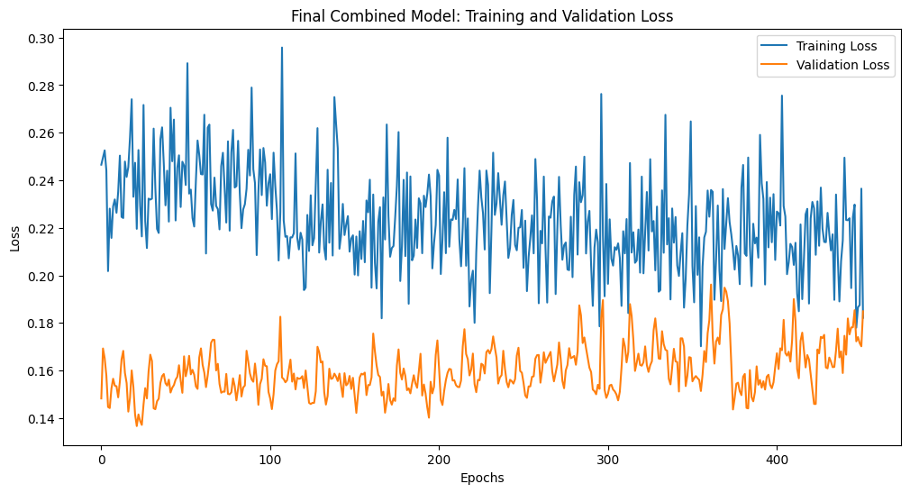

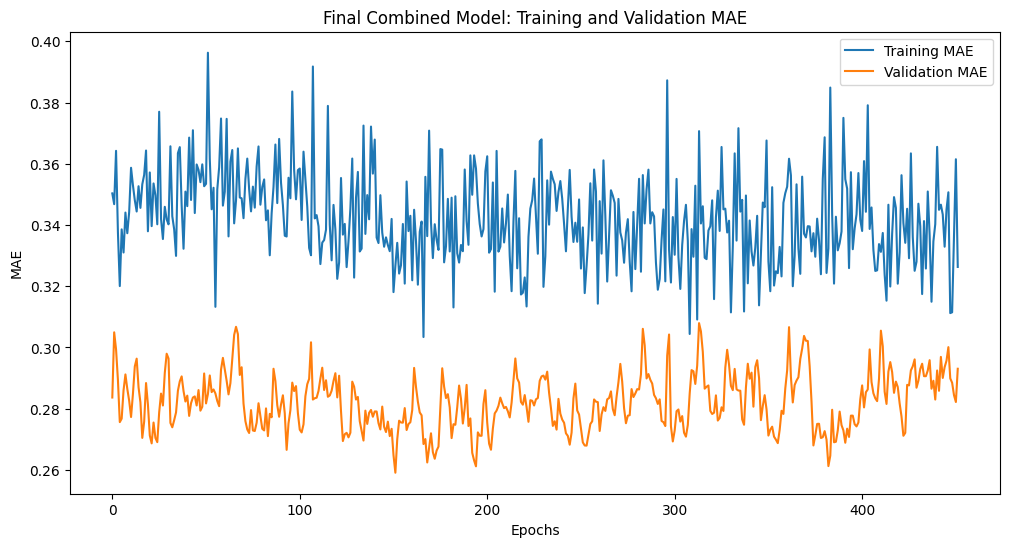

```python
print(f"Final Combined Model - Test Loss: {final_combined_test_loss}, Test MAE: {final_combined_test_mae}")

# Plot training and validation loss for the final combined model
plt.figure(figsize=(12, 6))
plt.plot(history_final_combined.history['loss'], label='Training Loss')
plt.plot(history_final_combined.history['val_loss'], label='Validation Loss')
plt.title('Final Combined Model: Training and Validation Loss')
plt.xlabel('Epochs')
plt.ylabel('Loss')
plt.legend()
plt.show()

# Plot training and validation MAE for the final combined model
plt.figure(figsize=(12, 6))
plt.plot(history_final_combined.history['mae'], label='Training MAE')
plt.plot(history_final_combined.history['val_mae'], label='Validation MAE')
plt.title('Final Combined Model: Training and Validation MAE')
plt.xlabel('Epochs')
plt.ylabel('MAE')
plt.legend()
plt.show()
```